# Simplification

Stat 365: Statistical Communication

## Wednesday, May 3rd<sup>1</sup>

Today we will…

- Design Principles
- Bad Graphics Day
- Copy the Masters
[^1]: Material for today’s lecture is from [Amelia McNamara](https://www.amelia.mn/STAT336/index.html)

# Design Principles

## Principle 1: expressiveness<sup>1</sup>

Encode all the facts.

Encode only the facts.

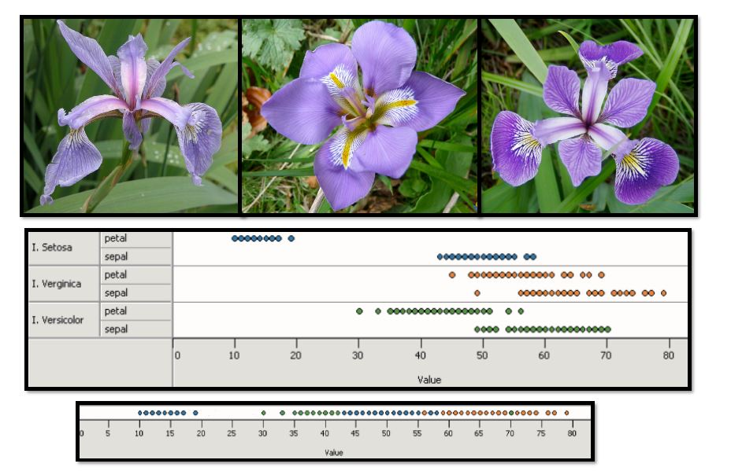

[^2]: via Jordan Crouser

## Principle 2: consistency<sup>1</sup>

Use consistent axes when comparing charts.

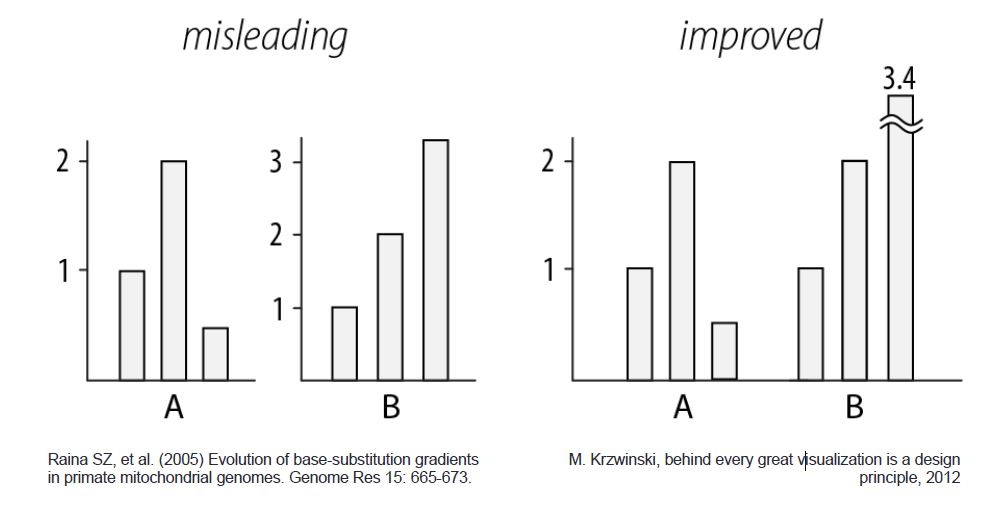

[^3]: via Jordan Crouser

## Principle 2: consistency<sup>1</sup>

A note on legends: order items according to appearance.

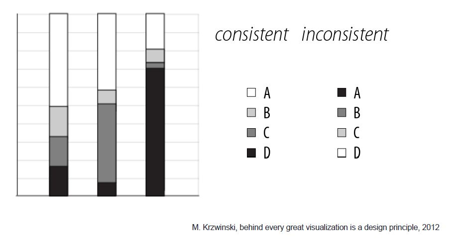

[^4]: via Jordan Crouser

## Principle 2: consistency<sup>1</sup>

Visual variation should reflect and enhance the underlying variation in the data.

Avoid visually similar encodings for independent variables.

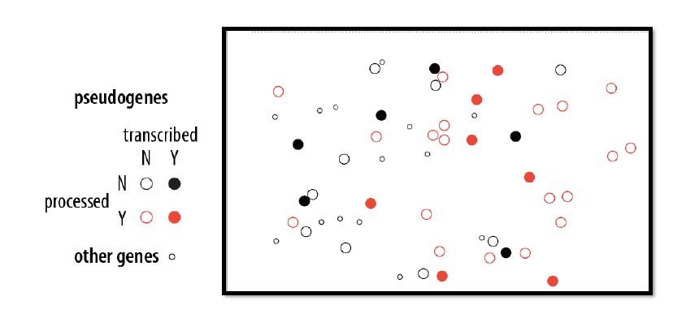

[^5]: via Jordan Crouser

## Principle 3: importance ordering<sup>1</sup>

Avoid unnecessary containment and repetition.

Navigational aids shouldn’t compete with data.

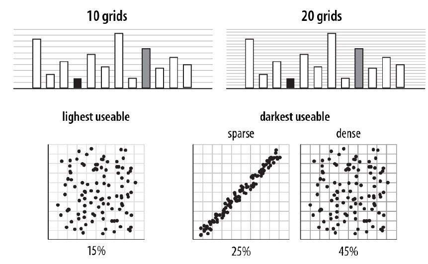

[^6]: Heer J, Bostock M (2010) Crowdsourcing graphical perception: using mechanical turk to assess visualization design. Proceedings of the 28th international conference on Human factors in computing systems.

## Principle 3: importance ordering<sup>1</sup>

- use a reasonable number of slices, aggregating minor categories if necessary
- order the slices by size from the largest to the smallest
- place the ’Other’ slice at the end of the sequence, regardless of the order scheme
- position the first and largest slice against the upper vertical radius, and arrange the other slices in a clockwise fashion
- vary colors only if the colors are encoding data.

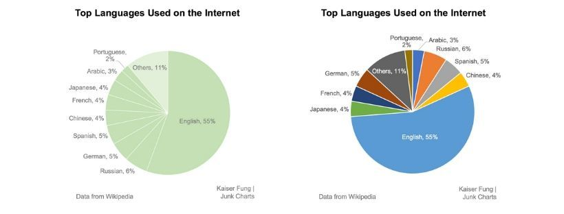

[^7]: https://datajournalism.com/read/longreads/the-unspoken-rules-of-visualisation-and-when-to-break-them

## Principle 3: importance ordering<sup>1</sup>

Simplify, simplify, simplify!

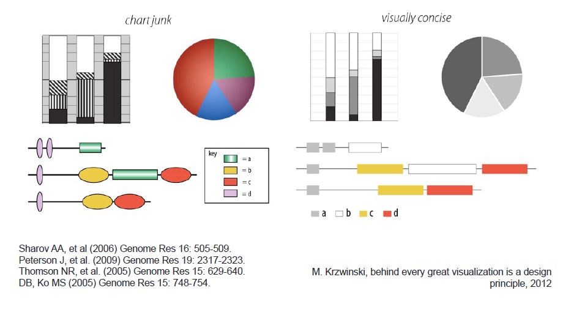

[^8]: via Jordan Crouser

## Tufte and the data-ink ratio

data-ink ratio = data ink / total ink used to print the graphic

= proportion of a graphic’s ink devoted to the non-redundant display of data-information

= 1 - proportion of a graphic that can be erased

<sup>1</sup>

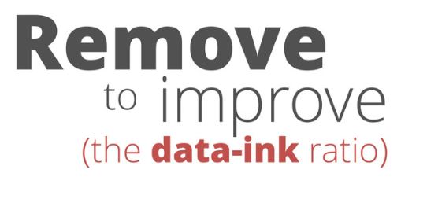

[^9]: https://www.darkhorseanalytics.com/blog/data-looks-better-naked/

## Polish your graphic!

- Title
- Footnote
- Caption
- Alt Text
- Keep it concise, clear, and descriptive.
- Use active voice and avoid jargon.
- Highlight the main message or point of the graphic.
- Consider using a subtitle to provide additional context or information.
- You may consider including your legend in the title.
- Include all necessary information, such as data source.
- Place the footnote at the bottom of the graphic or immediately after the graphic.
- Avoid using footnotes to provide additional analysis or interpretation.
- Describe what has been plotted.
- Orient the reader.
- Point out important features of the plot and implications.
- It is okay for captions to repeat information found in the text.
- Provide a brief but informative description of the graphic’s content for users who cannot see it.
- Use plain language and avoid abbreviations or symbols that may be unfamiliar to some users.
- Describe the key variables, trends, and patterns shown in the graphic.
- Test the alternative text with screen reader software to ensure it accurately conveys the content of the graphic.

.Rmd `fig.alt =`

.qmd `#| fig-alt:`

## Bad Graphics Day!

Apply what we know about graphical perception to the visualizations.

(Can complete in pairs)

1. Visit http://viz.wtf/ and pick your favorite “bad graphic”.
2. Upload a copy to the [Google slide deck](https://docs.google.com/presentation/d/1SJrci-UHCZL8pqSpTOLIsH30MGLUcUefsqmTJpsf4w0/edit?usp=sharing).
3. Add a short description or bullet point list of how the graph violates perceptual and design principles.
4. Both of you should copy the URL for your slide and upload it to the Canvas assignment.

## Question to ponder: should visualizations be immediately readable, or should you need to study them?

# [Copy the Masters](https://earobinson95.github.io/stat365-calpoly/97-mini-projects/copy-the-masters/copy-the-masters.html)

## To do

**Data and Methods + Table**

- due Thursday, 5/4
- You will need to include your statistical methods.
- REPRODUCIBILITY! Document EVERYTHING!
- **Read CwD 3.4:** Tracking the Analysis

**Bad Graphics Day**

- due TONIGHT, 5/3 at 11:59pm

**CwD ch. 7.1 - 7.5, (optional) 8.1 - 8.7**

- for class next week

**Copy the Masters: Pick your Graphic**

- due Thursday, 5/11 at 11:59pm